# Statistical Methods for Insurance: Generalised Linear Models

W7.C2

## Generalised linear models

- Overview
- Types
- Assumptions
- Fitting
- Examples

## Overview

- GLMs are a broad class of models for fitting different types of response variables distributions.
- The multiple linear regression model is a special case.

## Three components

- Random Component: probability distributin of the response variable
- Systematic Component: explanatory variables
- Link function: describes the relaionship between the random and systematic components

## Multiple linear regression

\[y_i = \beta_0+\beta_1x_1 + \beta_2x_2 + \varepsilon ~~~ or ~~~ E(Y_i)=\beta_0+\beta_1x_1+\beta_2x_2\]

- Random component: \(y_i\) has a normal distribution, and so \(e_i \sim N(0,\sigma^2)\)
- Systematic component: \(\beta_0+\beta_1x_1 + \beta_2x_2\)
- Link function: identity, just the systematic component

## Poisson regression

\[y_i = exp(\beta_0+\beta_1x_1+\beta_2x_2) + \varepsilon\]

- \(y_i\) takes integer values, 0, 1, 2, …
- Link function: \(ln(\mu)\), name=`log`. (Think of \(\mu\) as \(\hat{y}\).)

## Bernouilli, binomial regression

\[y_i = \frac{exp(\beta_0+\beta_1x_1+\beta_2x_2)}{1+exp(\beta_0+\beta_1x_1+\beta_2x_2)} + \varepsilon\]

- \(y_i\) takes integer values, \(\{ 0, 1\}\) (bernouilli), \(\{ 0, 1, ..., n\}\) (binomial)
- Let \(\mu=\frac{exp(\beta_0+\beta_1x_1+\beta_2x_2)}{1+exp(\beta_0+\beta_1x_1+\beta_2x_2)}\), link function is \(ln\frac{\mu}{1-\mu}\), name=`logit`

## Assumptions

- The data \(y_1, y_2, ..., y_n\) are independently distributed, i.e., cases are independent.
- The dependent variable \(y_i\) does NOT need to be normally distributed, but it typically assumes a distribution from an exponential family (e.g. binomial, Poisson, multinomial, normal,…)
- Linear relationship between the transformed response (see examples below)
- Explanatory variables can be transformations of original variables
- Homogeneity of variance does NOT need to be satisfied
- Uses maximum likelihood estimation (MLE) to estimate the parameters
- Goodness-of-fit measures rely on sufficiently large samples

## Example: Olympics medal tally

- Model medal counts on log_GDP
- Medal counts = integer, suggests use a Poisson model.

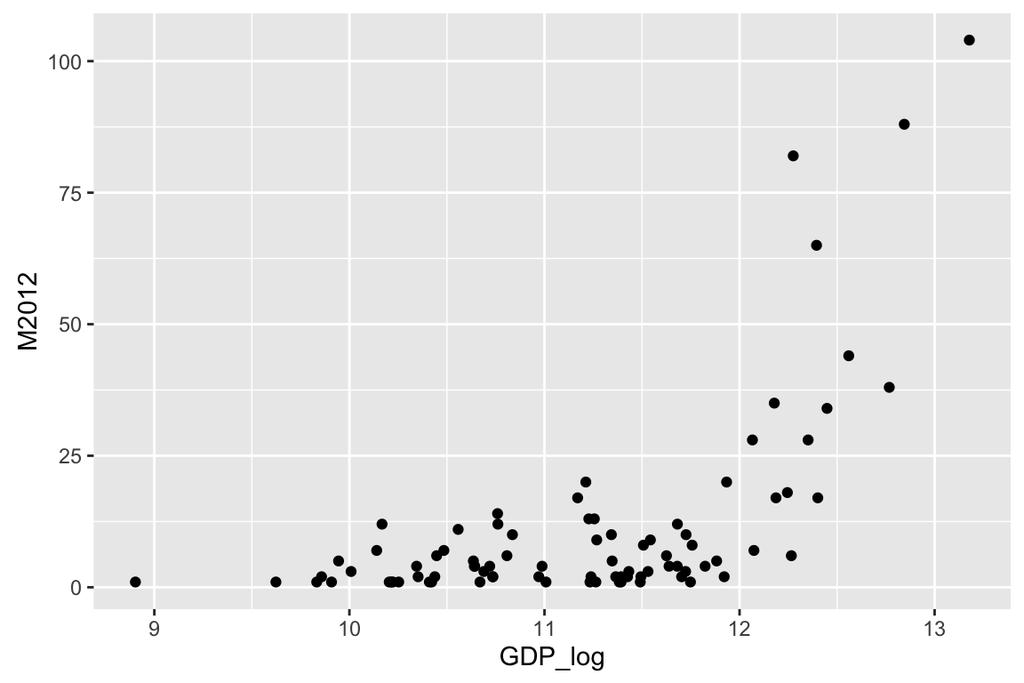

```r
oly_glm <- glm(M2012~GDP_log, data=oly_gdp2012,
               family=poisson(link=log))
```

|  | Estimate | Std. Error | z value | Pr(>\|z\|) |
| --- | --- | --- | --- | --- |
| (Intercept) | -13.2 | 0.54 | -24 | 0 |
| GDP_log | 1.3 | 0.04 | 30 | 0 |

## Your turn

Write down the formula of the fitted model.

## What does this model look like?

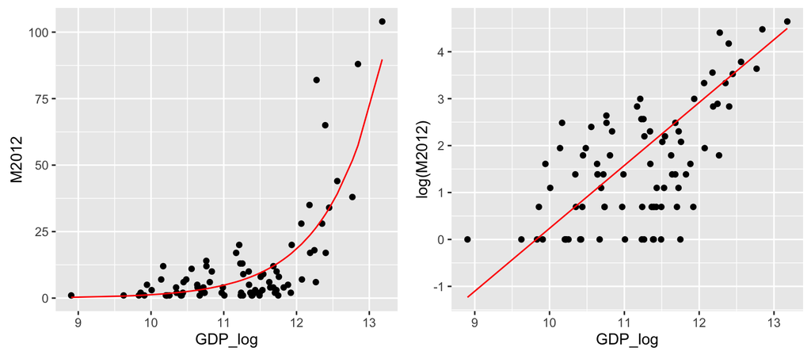

## Example: winning tennis matches

We have data scraped from the web sites of the 2012 Grand Slam tennis tournaments. There are a lot of statistics on matches. Below we have the number of receiving points won, and whether the match was won or not.

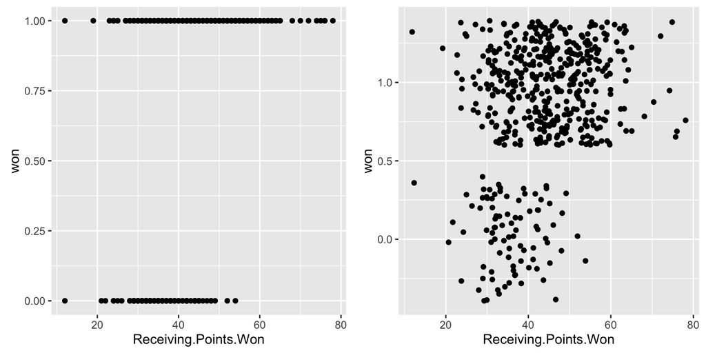

## Your turn

The response variable is binary. What type of GLM should be fit?

## Model

```r
tennis_glm <- glm(won~Receiving.Points.Won, data=tennis,
                  family=binomial(link='logit'))
```

|  | Estimate | Std. Error | z value | Pr(>\|z\|) |
| --- | --- | --- | --- | --- |
| (Intercept) | -2.91 | 0.59 | -5.0 | 0 |
| Receiving.Points.Won | 0.11 | 0.02 | 7.3 | 0 |

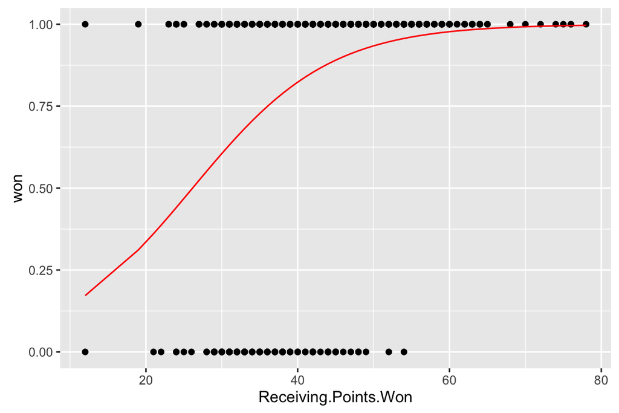

## Your turn

Write down the fitted model

## Resources

- [Beginners guide](https://www.analyticsvidhya.com/blog/2015/11/beginners-guide-on-logistic-regression-in-r/)
- [Introduction to GLMs](https://onlinecourses.science.psu.edu/stat504/node/216)
- [Quick-R GLMs](http://www.statmethods.net/advstats/glm.html)
- [The Analysis Factor, Generalized Linear Models Parts 1-4](http://www.theanalysisfactor.com/resources/by-topic/r/)
- [wikipedia](https://en.wikipedia.org/wiki/Generalized_linear_model)
- [Do Smashes Win Matches?](http://onlinelibrary.wiley.com/doi/10.1111/j.1740-9713.2013.00665.x/full)

## Share and share alike

This work is licensed under the Creative Commons Attribution-Noncommercial 3.0 United States License. To view a copy of this license, visit http://creativecommons.org/licenses/by-nc/ 3.0/us/ or send a letter to Creative Commons, 171 Second Street, Suite 300, San Francisco, California, 94105, USA.